# n-gram milestone report

yinshu zhang

November 7, 2019

# background

This report is a peer-graded assignment, requirement can be found https://www.coursera.org/learn/data-science-project/peer/BRX21/milestone-report.

The goal of this project is to create a n-gram model, A n-gram model is a type of probabilitstic language model, for predicting next word or words base on given input. Before using n-gram to find the correlation and relationships of word, We will conduct a simple exploratory analysis of input text.

This report shows the frequency of words, lot of time we interested in what is mentioned amount set of text, for example in newspaper, what word is used more than others.

The input data we use is provided by SwiftKey, there are 3 files in English we will use, news, blogs, and tweeter.

```r
#url <- "https://d396qusza40orc.cloudfront.net/dsscapstone/dataset/Coursera-SwiftKey.zip"
#download(url, dest="dl.zip", mode="wb")
#unzip('dl.zip', exdir="./")
```

# clean up by removing meaningless

`unnest_token` function in tidytext provide convinent way to split lines into token, it does *NOT* require preprocess input text, in the past we need to “cleanup” text, for example remove non-ascii charactors, punctuations, remove or emoji, current software can tokenize text without this CPU comsuming step.

Our clean up is focus on removing stop words. Stop words are words that are not useful for an analysis, typically extremely common words such as “the”, “of”, “to” etc., we will use anti-join `stop_words` from tidytext against.

Below function `get_word_cnt` involves three simple steps, tokenizing, remove stop words, count and sort, in the end it return a list of frequency of words, two columns are word, and frequency(n).

```r
# return sorted frequency of token(word)
get_word_cnt <- function(input) {
  words <- tibble(text = input) %>% unnest_tokens(word, text)
  words <- words %>% anti_join(stop_words, by="word")
#  kintr prompt error, use gsub outside of function
#  words <- gsub('\\d+', '', words)
  word_cnt <- words %>% count(word, sort=T)
  word_cnt
}
```

# analysis

The report present three analysis, on each file, first “news”

```r
# read file
#news <- readLines("./final/en_US/en_US.news.txt", encoding = "UTF-8", skipNul = T, n=10000)
news <- readLines("./final/en_US/en_US.news.txt", encoding = "UTF-8", skipNul = T)
news <- gsub('\\d+', '', news)
# count word frequency
word_cnt <- get_word_cnt(news)
```

## distribution of frequence

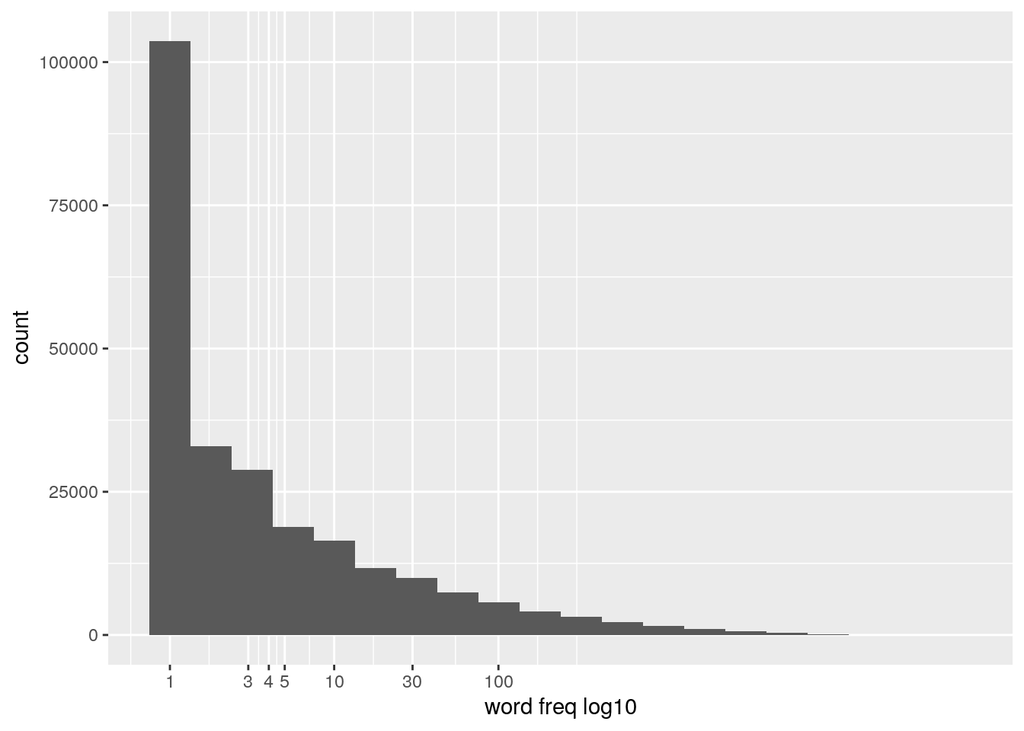

```r
# distribution of word frequence
word_cnt %>%  ggplot(aes(n)) +  geom_histogram(bins = 20) +
  scale_x_continuous(trans = "log10", breaks = c(0,1,3,4,5,10,30,100)) +
  xlab("word freq log10")
```

## top words

Now we want to see frequent word, below are top 20

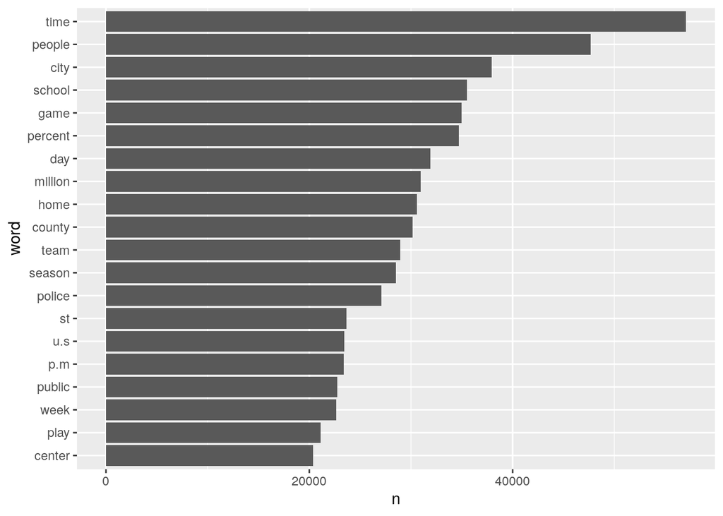

```r
# plot top 20 word freq
word_cnt %>% filter(n >= as.integer(word_cnt[20,2]) ) %>%
  mutate(word=reorder(word,n)) %>%
  ggplot(aes(word,n)) + geom_col()+ coord_flip()
```

## word cloud

lastly, word cloud gives good visual of freqent word, bigger the font, more frequent it appears.

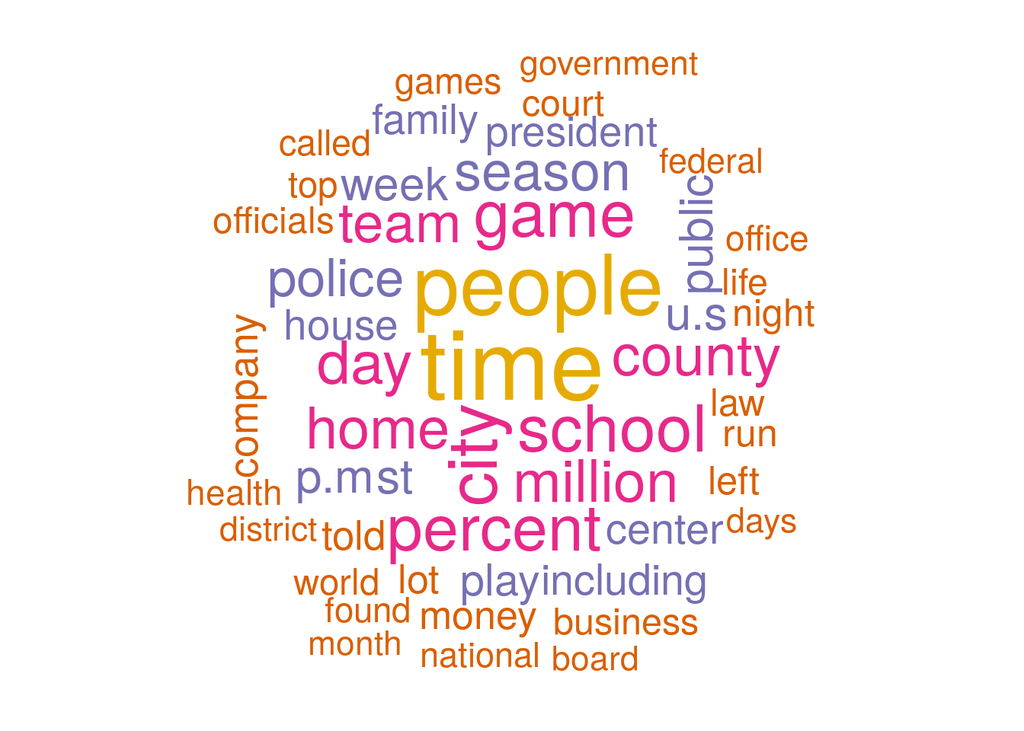

```r
# cloud
word_cnt %>% with(wordcloud(word, n, random.order=F, max.words = 50, colors=brewer.pal(6,"Dark2")))
```

## blog

same analysis for blog

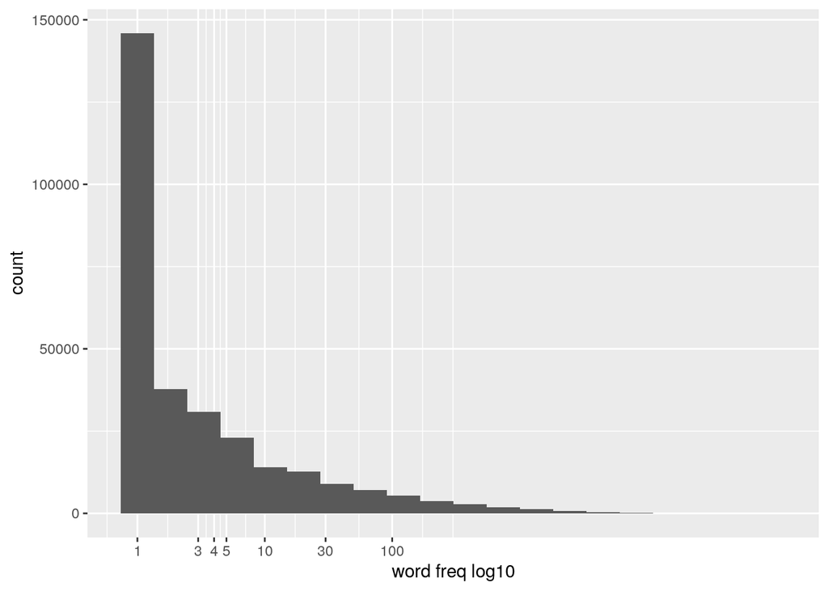

```r
blogs <- readLines("./final/en_US/en_US.blogs.txt", encoding = "UTF-8", skipNul = T)
blogs <- gsub('\\d+', '', blogs)
word_cnt <- get_word_cnt(blogs)
word_cnt %>%  ggplot(aes(n)) +  geom_histogram(bins = 20) +
  scale_x_continuous(trans = "log10", breaks = c(0,1,3,4,5,10,30,100)) +
  xlab("word freq log10")
```

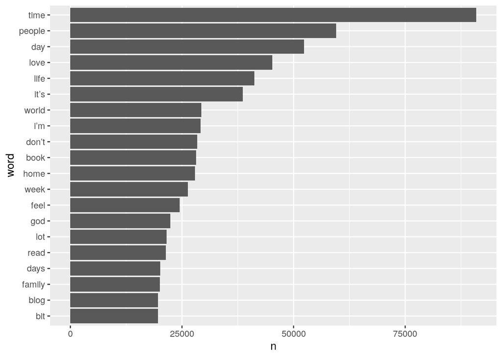

```r
word_cnt %>% filter(n >= as.integer(word_cnt[20,2]) ) %>%
  mutate(word=reorder(word,n)) %>%
  ggplot(aes(word,n)) + geom_col()+ coord_flip()
```

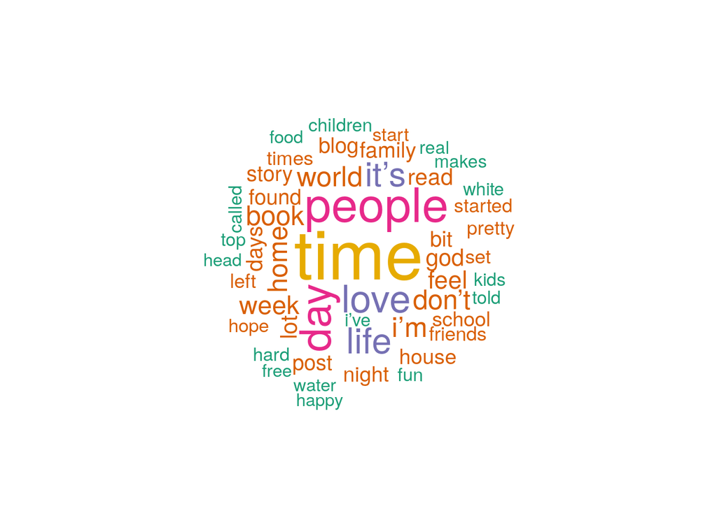

```r
word_cnt %>% with(wordcloud(word, n, random.order=F, max.words = 50, colors=brewer.pal(6,"Dark2")))
```

*total word: 14118430, number of unique word 296711*

## Tweets

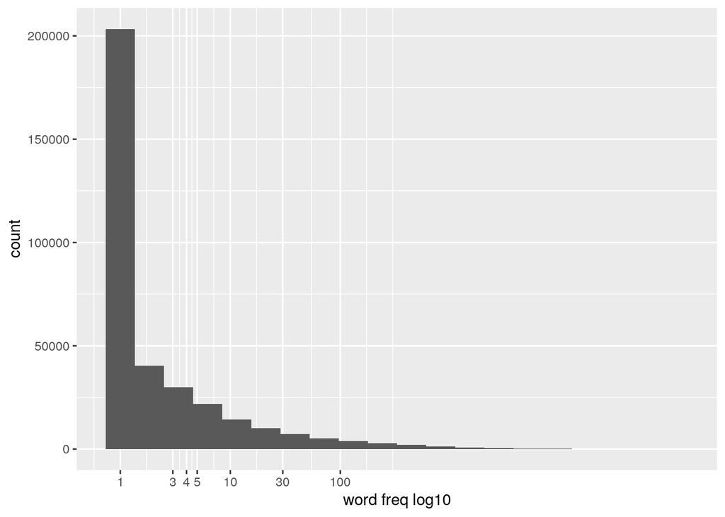

```r
tw <- readLines("./final/en_US/en_US.twitter.txt", encoding = "UTF-8", skipNul = T)
tw <- gsub('\\d+', '', tw)
word_cnt <- get_word_cnt(tw)
word_cnt %>%  ggplot(aes(n)) +  geom_histogram(bins = 20) +
  scale_x_continuous(trans = "log10", breaks = c(0,1,3,4,5,10,30,100)) +
  xlab("word freq log10")
```

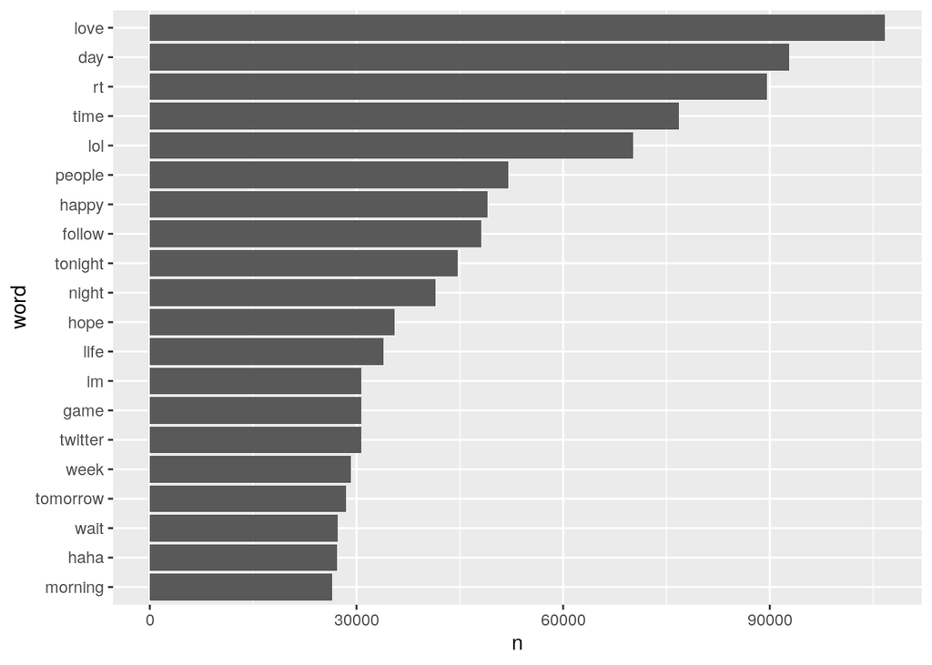

```r
word_cnt %>% filter(n >= as.integer(word_cnt[20,2]) ) %>%
  mutate(word=reorder(word,n)) %>%
  ggplot(aes(word,n)) + geom_col()+ coord_flip()
```

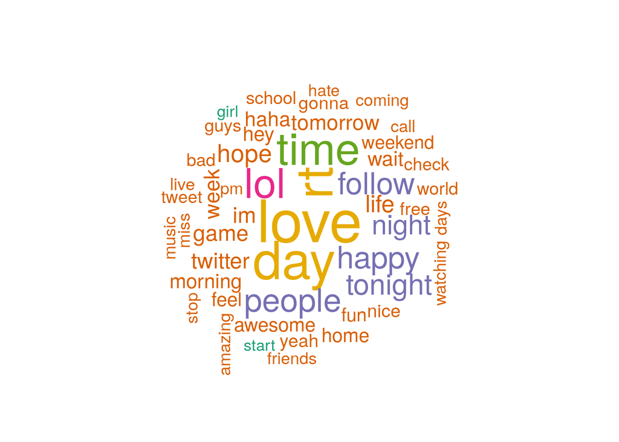

```r
word_cnt %>% with(wordcloud(word, n, random.order=F, max.words = 50, colors=brewer.pal(6,"Dark2")))
```

*total word: 11993730, number of unique word 344710*